# phenoR downloads

## tutorial - PhenocamR packages

https://www.neonscience.org/resources/learning-hub/tutorials/phenocam-phenor-modeling

For the latest version, install `phenor` from here: https://github.com/bluegreen-labs/phenor (be sure to update all packages for installation to work, and install GenSA)

See a map of phenocam sites [here](https://phenocam.nau.edu/webcam/network/map/)

```r
# change my_site to the phenocam site you are looking at
my_site = "NEON.D02.SERC.DP1.00033"

# can see rois to select where to download(regions of interest)
list_rois() %>%
  filter(site==my_site)
```

```
##                      site      lat       lon veg_type roi_id_number
## 1 NEON.D02.SERC.DP1.00033 38.89008 -76.56001       DB             1
## 2 NEON.D02.SERC.DP1.00033 38.89008 -76.56001       DB             2
## 3 NEON.D02.SERC.DP1.00033 38.89008 -76.56001       DB             3
## 4 NEON.D02.SERC.DP1.00033 38.89008 -76.56001       DB             4
## 5 NEON.D02.SERC.DP1.00033 38.89008 -76.56001       DB          1000
##                     description first_date  last_date site_years
## 1                General canopy 2016-02-22 2018-03-12        1.8
## 2                   front trees 2016-01-29 2018-03-12        1.9
## 3              background trees 2016-01-29 2018-03-12        1.9
## 4              background trees 2016-01-29 2018-03-12        1.9
## 5 canopy level DB in foreground 2016-01-29 2025-03-27        8.9
##   missing_data_pct
## 1               11
## 2               11
## 3               11
## 4               11
## 5                2
```

```r
# roi id 1000 has been around the longest with least amount of missing data, makese sense to use as example
```

```r
# download phenocam - this should create 2 csv files
phenocamr::download_phenocam(
  veg_type = "DB", #DB for decid broadleaf, EN for evergreen, default is ALL
  roi_id = 1000,
  site = my_site,
  phenophase = TRUE,
  out_dir = "." # saves in directory
  )
```

The data is set up as a `phenocamr` type, which includes a list with metadata and timeseries data.

Let’s repeat this process for MLBS site.

```r
# change my_site to the phenocam site you are looking at
my_site2 = "NEON.D07.MLBS.DP1.00033"

# can see rois to select where to download(regions of interest)
list_rois() %>%
  filter(site==my_site2)
```

```
##                      site      lat       lon veg_type roi_id_number
## 1 NEON.D07.MLBS.DP1.00033 37.37831 -80.52485       DB             1
## 2 NEON.D07.MLBS.DP1.00033 37.37831 -80.52485       DB             2
## 3 NEON.D07.MLBS.DP1.00033 37.37831 -80.52485       DB          1000
## 4 NEON.D07.MLBS.DP1.00033 37.37831 -80.52485       DB          2000
## 5 NEON.D07.MLBS.DP1.00033 37.37831 -80.52485       EN             1
##                               description first_date  last_date site_years
## 1                        deciduous forest 2016-12-15 2018-03-12        1.0
## 2      deciduous forest in the background 2016-12-15 2018-03-12        1.0
## 3           canopy level DB in foreground 2016-12-15 2018-03-30        0.1
## 4 canopy level DB in foreground (AWB off) 2018-03-30 2025-03-27        6.7
## 5    pine tree in the right bottom corner 2017-01-05 2018-03-12        1.1
##   missing_data_pct
## 1               17
## 2               17
## 3               89
## 4                3
## 5                6
```

```r
# roi id 2000 has 6.7 years with least amount of missing data
```

```r
# download phenocam - this should create 2 csv files
phenocamr::download_phenocam(
  veg_type = "DB", #DB for decid broadleaf, EN for evergreen, default is ALL
  roi_id = 2000,
  site = my_site2,
  phenophase = TRUE,
  out_dir = "." # saves in directory
  )
```

## following steps from phenocamr vignette

[see website here](https://bluegreen-labs.github.io/phenocamr/articles/phenocamr-vignette.html)

source has clear steps, but uses base plotting, below I create same plot with ggplot. In this plot, the green line represents date when green up has reached 50%, and the red line represents date when 50% of gcc was lost. To see how this is calculated, check out the figures on page 6 of the phenocam access guide.

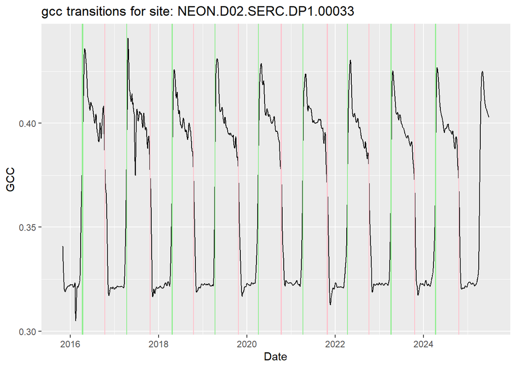

```r
# read as phenocamr type
df = read_phenocam(paste(my_site,"_DB_1000_3day.csv", sep=""))

df <- expand_phenocam(df) # expand every 3 day to every day

df <- detect_outliers(df) # detect outliers

df <- smooth_ts(df) # smooth data using AIC

phenology_dates <- phenophases(df, internal = TRUE) # calculate rising and falling

site1_plot = as.data.frame(df$data) %>%
  mutate(date = as.Date(date)) %>%
  ggplot(aes(x=date, y=smooth_gcc_90)) +
  geom_line() +
  labs(x="Date", y="GCC") +
  # rising "spring" greenup dates
  geom_vline(data=phenology_dates$rising, aes(xintercept=transition_50), col="lightgreen") +
  # falling 'autumn' senescence dates
  geom_vline(data=phenology_dates$falling, aes(xintercept=transition_50), col="pink")+
  ggtitle(paste("gcc transitions for site:", my_site))

site1_plot
```

We can compare our two sites.

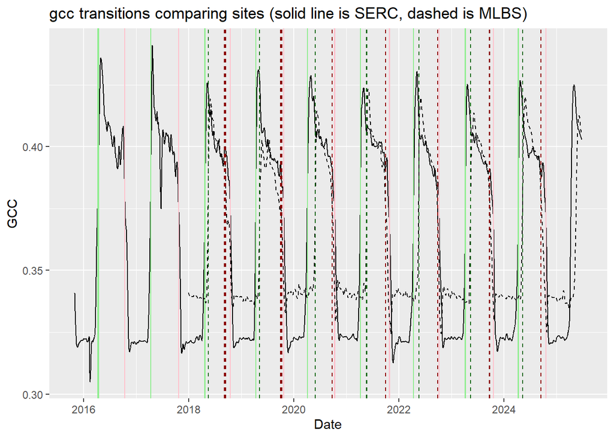

```r
# read as phenocamr type
df2 = read_phenocam(paste(my_site2,"_DB_2000_3day.csv", sep=""))

df2 <- expand_phenocam(df2) # expand every 3 day to every day
df2 <- detect_outliers(df2) # detect outliers
df2 <- smooth_ts(df2) # smooth data using AIC

phenology_dates2 <- phenophases(df2, internal = TRUE) # calculate rising and falling

site2 = as.data.frame(df2$data) %>%
  mutate(date = as.Date(date))

site1_plot +
  geom_line(data=site2, aes(x=date, y=smooth_gcc_90), linetype='dashed') +
  # rising "spring" greenup dates
  geom_vline(data=phenology_dates2$rising, aes(xintercept=transition_50), col="darkgreen", linetype='dashed') +
  # falling 'autumn' senescence dates
  geom_vline(data=phenology_dates2$falling, aes(xintercept=transition_50), col="darkred", linetype="dashed")+
  ggtitle("gcc transitions comparing sites (solid line is SERC, dashed is MLBS)")
```

For spring Green up, we will focus on the `phenology_dates$rising` data frame.

Columns are labeled as `transition` with a number, where the number represents at what percentage the amount of green up has reached. 10% is when leaves begin to emerge in the spring. The transition column values are dates.

There are also `threshold` columns which correspond to the GCC value at that transition date.

```r
head(phenology_dates2$rising)
```

```
##   gcc_value transition_10 transition_25 transition_50 transition_10_lower_ci
## 1    gcc_90         17661         17664         17668                  17660
## 2    gcc_90         18018         18021         18025                  18017
## 3    gcc_90         18403         18408         18412                  18401
## 4    gcc_90         18763         18765         18769                  18762
## 5    gcc_90         19124         19127         19131                  19122
## 6    gcc_90         19484         19487         19491                  19483
##   transition_25_lower_ci transition_50_lower_ci transition_10_upper_ci
## 1                  17663                  17667                  17663
## 2                  18020                  18024                  18020
## 3                  18407                  18411                  18406
## 4                  18764                  18768                  18764
## 5                  19126                  19130                  19126
## 6                  19486                  19490                  19486
##   transition_25_upper_ci transition_50_upper_ci threshold_10 threshold_25
## 1                  17666                  17669      0.34597      0.35724
## 2                  18022                  18026      0.34369      0.35352
## 3                  18409                  18413      0.34730      0.35825
## 4                  18767                  18770      0.34815      0.35680
## 5                  19128                  19132      0.34737      0.35707
## 6                  19488                  19492      0.34459      0.35743
##   threshold_50 min_gcc max_gcc
## 1      0.37959 0.33981 0.41875
## 2      0.37148 0.33884 0.40200
## 3      0.37791 0.34090 0.41400
## 4      0.38373 0.34046 0.42285
## 5      0.38386 0.33993 0.41946
## 6      0.37702 0.33955 0.41309
```

Next I am going to simplify this data so it is easier to work with, then save as a new CSV file.

```r
# combine data frame
phenology_dates$rising$site = my_site
phenology_dates2$rising$site = my_site2

phenology_dates_sites = rbind(phenology_dates$rising, phenology_dates2$rising)

date_cols = colnames(phenology_dates_sites)[2:10]

# filter to gcc_Value, change date columns to format as date
phen_tosave = phenology_dates_sites %>%
  filter(gcc_value=="gcc_90") %>%
  mutate_at(all_of(date_cols), list(as.Date)) %>%
  # can also get year and doy for transitions
  mutate(year = year(transition_50),
         doy50 = yday(transition_50),
         doy25 = yday(transition_25),
         doy10 = yday(transition_10))
# preview
head(phen_tosave)
```

```
##   gcc_value transition_10 transition_25 transition_50 transition_10_lower_ci
## 1    gcc_90    2016-03-25    2016-03-29    2016-04-11             2016-03-24
## 2    gcc_90    2017-03-29    2017-04-04    2017-04-12             2017-03-21
## 3    gcc_90    2018-04-10    2018-04-16    2018-04-24             2018-04-09
## 4    gcc_90    2019-04-04    2019-04-08    2019-04-12             2019-04-03
## 5    gcc_90    2020-03-19    2020-03-27    2020-04-05             2020-03-17
## 6    gcc_90    2021-03-30    2021-04-03    2021-04-08             2021-03-29
##   transition_25_lower_ci transition_50_lower_ci transition_10_upper_ci
## 1             2016-03-28             2016-04-07             2016-03-27
## 2             2017-03-21             2017-03-21             2017-04-20
## 3             2018-04-15             2018-04-22             2018-04-12
## 4             2019-04-07             2019-04-11             2019-04-06
## 5             2020-03-26             2020-04-03             2020-03-23
## 6             2021-04-02             2021-04-07             2021-04-01
##   transition_25_upper_ci transition_50_upper_ci threshold_10 threshold_25
## 1             2016-03-31             2016-04-13      0.33212      0.34727
## 2             2017-04-20             2017-04-20      0.33207      0.34932
## 3             2018-04-18             2018-04-25      0.33019      0.34678
## 4             2019-04-09             2019-04-13      0.33126      0.34878
## 5             2020-03-30             2020-04-06      0.33176      0.34643
## 6             2021-04-05             2021-04-09      0.33714      0.35211
##   threshold_50 min_gcc max_gcc                    site year doy50 doy25 doy10
## 1      0.37822 0.32171 0.43443 NEON.D02.SERC.DP1.00033 2016   102    89    85
## 2      0.38354 0.32113 0.43892 NEON.D02.SERC.DP1.00033 2017   102    94    88
## 3      0.37706 0.32125 0.42513 NEON.D02.SERC.DP1.00033 2018   114   106   100
## 4      0.37725 0.32222 0.43068 NEON.D02.SERC.DP1.00033 2019   102    98    94
## 5      0.38012 0.32259 0.42796 NEON.D02.SERC.DP1.00033 2020    96    87    79
## 6      0.37869 0.33039 0.42346 NEON.D02.SERC.DP1.00033 2021    98    93    89
```

```
# save csv
write.csv(phen_tosave, "../data/SERC_MLBS_spring_dates.csv")
```